# 북한의 가뭄 변동과 지역별 쌀 가격의 관계: 평양·신의주·혜산 월별 패널자료를 이용한 실증분석

저자

정주희

공개

2026년 9월 25일

# 1. Initial setting

## Loading packages

**코드 보기**

```r
source("code/00_initial.R")
```

Back to top

# 2. Data preparation

## 2.1 Data import and preprocessing

### Precipitation data

The daily precipitation data cover 27 weather stations from January 1973 to July 2026. The precipitation variable has a missing rate of 66.28%. Missing precipitation values are addressed in scripts `02_00`–`02_07` before aggregation to the monthly level.

**코드 보기**

```r
precip_summary <- tibble(
  item = c(
    "Number of weather stations",
    "Start date",
    "End date",
    "Total observations",
    "Observed precipitation",
    "Missing precipitation",
    "Missing rate (%)",
    "Zero precipitation",
    "Positive precipitation"
  ),
  value = c(
    n_distinct(weather_daily_raw$station),
    as.character(min(weather_daily_raw$date, na.rm = TRUE)),
    as.character(max(weather_daily_raw$date, na.rm = TRUE)),
    format(
      nrow(weather_daily_raw),
      big.mark = ",",
      scientific = FALSE
    ),
    format(
      sum(!is.na(weather_daily_raw$precipitation_total_day)),
      big.mark = ",",
      scientific = FALSE
    ),
    format(
      sum(is.na(weather_daily_raw$precipitation_total_day)),
      big.mark = ",",
      scientific = FALSE
    ),
    round(
      mean(is.na(weather_daily_raw$precipitation_total_day)) * 100,
      2
    ),
    format(
      sum(
        weather_daily_raw$precipitation_total_day == 0,
        na.rm = TRUE
      ),
      big.mark = ",",
      scientific = FALSE
    ),
    format(
      sum(
        weather_daily_raw$precipitation_total_day > 0,
        na.rm = TRUE
      ),
      big.mark = ",",
      scientific = FALSE
    )
  )
)

knitr::kable(
  precip_summary,
  col.names = c("Item", "Value"),
  align = c("l", "c"),
  caption = "Summary of daily precipitation data"
)
```

Summary of daily precipitation data

| Item | Value |
| --- | --- |
| Number of weather stations | 27 |
| Start date | 1973-01-01 |
| End date | 2026-07-31 |
| Total observations | 476,297 |
| Observed precipitation | 160,626 |
| Missing precipitation | 315,671 |
| Missing rate (%) | 66.28 |
| Zero precipitation | 45,078 |
| Positive precipitation | 115,548 |

### Rice price data (Daily NK)

Rice price observations for Pyongyang, Sinuiju, and Hyesan are aggregated to monthly averages. The data cover January 2013 to July 2026. Months without observations are retained as missing.

**코드 보기**

```r
rice_summary <- tibble(
  item = c(
    "Number of original observations",
    "Start date",
    "End date",
    "Number of total months",
    "Number of observed months",
    "Number of missing months"
  ),
  value = c(
    nrow(rice_price_obs),
    as.character(min(rice_price_obs$date, na.rm = TRUE)),
    as.character(max(rice_price_obs$date, na.rm = TRUE)),
    nrow(all_months),
    nrow(rice_price_monthly),
    nrow(missing_rice_months)
  )
)

knitr::kable(
  rice_summary,
  col.names = c("Item", "Value"),
  align = c("l", "c"),
  caption = "Summary of rice price data"
)
```

Summary of rice price data

| Item | Value |
| --- | --- |
| Number of original observations | 268 |
| Start date | 2013-01-09 |
| End date | 2026-07-19 |
| Number of total months | 163 |
| Number of observed months | 152 |
| Number of missing months | 11 |

Months without rice price observations are shown below. These months are retained as missing and are not interpolated.

**코드 보기**

```r
missing_rice_months |>
  knitr::kable(
    col.names = "Missing month",
    align = "c",
    caption = "Months without rice price observations"
  )
```

Months without rice price observations

| Missing month |
| --- |
| 2013-07 |
| 2013-10 |
| 2014-01 |
| 2015-03 |
| 2015-07 |
| 2015-11 |
| 2016-08 |
| 2017-05 |
| 2017-07 |
| 2017-10 |
| 2018-02 |

The following table reports descriptive statistics for monthly mean rice prices in the three study locations.

**코드 보기**

```r
rice_descriptive <- rice_price_monthly |>
  select(
    rice_pyongyang,
    rice_sinuiju,
    rice_hyesan
  ) |>
  pivot_longer(
    everything(),
    names_to = "region",
    values_to = "rice_price"
  ) |>
  mutate(
    region = recode(
      region,
      rice_pyongyang = "Pyongyang",
      rice_sinuiju   = "Sinuiju",
      rice_hyesan    = "Hyesan"
    )
  ) |>
  group_by(region) |>
  summarise(
    N    = sum(!is.na(rice_price)),
    Mean = mean(rice_price, na.rm = TRUE),
    SD   = sd(rice_price, na.rm = TRUE),
    Min  = min(rice_price, na.rm = TRUE),
    Max  = max(rice_price, na.rm = TRUE),
    .groups = "drop"
  )

knitr::kable(
  rice_descriptive,
  digits = 1,
  col.names = c(
    "Region",
    "N",
    "Mean",
    "SD",
    "Min",
    "Max"
  ),
  align = c("l", "c", "c", "c", "c", "c"),
  caption = "Descriptive statistics of monthly rice prices"
)
```

Descriptive statistics of monthly rice prices

| Region | N | Mean | SD | Min | Max |
| --- | --- | --- | --- | --- | --- |
| Hyesan | 152 | 7247.0 | 6040.1 | 4000 | 38600 |
| Pyongyang | 152 | 6944.3 | 5986.5 | 3700 | 38350 |
| Sinuiju | 152 | 6997.9 | 5989.7 | 3750 | 38350 |

The monthly series shows the evolution of rice prices across Pyongyang, Sinuiju, and Hyesan, with a marked acceleration in prices beginning in June 2025 and a particularly sharp increase in August 2025.

**코드 보기**

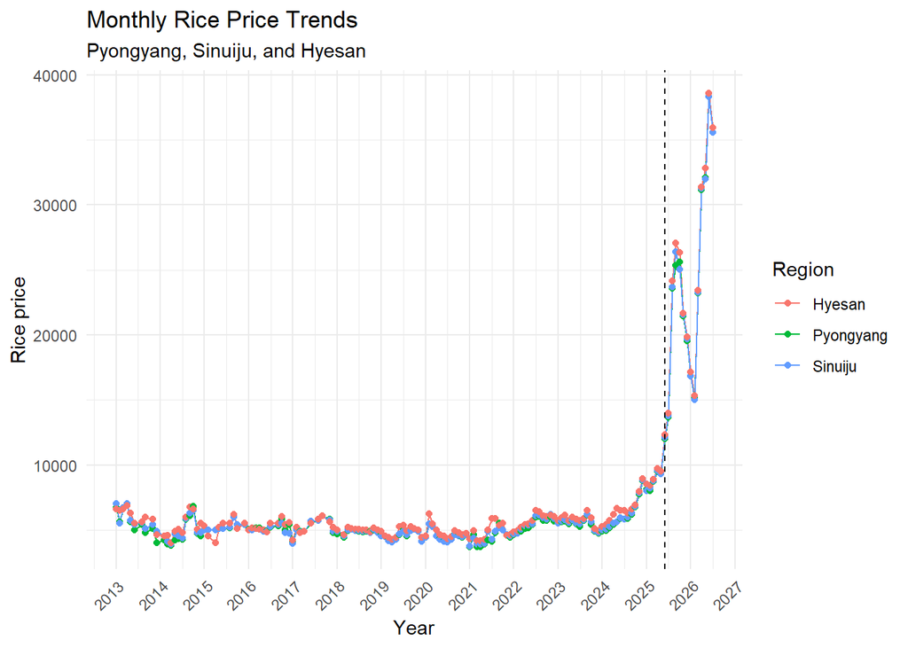

```r
rice_price_monthly_plot
```

For descriptive purposes, months in which rice prices increased by 20% or more from the preceding month are summarized below.

**코드 보기**

```r
knitr::kable(
  rice_price_increase_table,
  col.names = c(
    "Month",
    "Pyongyang",
    "Sinuiju",
    "Hyesan"
  ),
  align = c("l", "c", "c", "c"),
  caption = "Monthly rice price increases of 20% or more"
)
```

Monthly rice price increases of 20% or more

| Month | Pyongyang | Sinuiju | Hyesan |
| --- | --- | --- | --- |
| 2013-03 | – | 21.8% | – |
| 2014-05 | – | 20.5% | 22.5% |
| 2014-08 | 36.5% | 33.6% | 25% |
| 2015-05 | – | – | 30% |
| 2017-02 | 25% | 26.2% | 24.2% |
| 2020-02 | 21.7% | 23.6% | 37.2% |
| 2021-02 | 24.3% | – | – |
| 2021-06 | – | 24.1% | – |
| 2025-06 | 29% | 30.1% | 29.5% |
| 2025-08 | 72.9% | 72.4% | 73.1% |
| 2026-03 | 53.9% | 55.1% | 53.1% |
| 2026-04 | 34.1% | 34.3% | 34.1% |

Back to top

## Supplementary market data: AsiaPress

AsiaPress provides observations on rice, corn, fuel prices, and exchange rates in North Korean markets. Because the survey locations vary over time, these data do not represent a fixed regional price series or a national average. They are therefore used as supplementary evidence on broader market price movements rather than as the main dependent variable.

The monthly analysis covers April 2017 through August 2026. Months with no survey observations are retained explicitly as missing.

**코드 보기**

```r
asiapress_summary <- tibble(
  item = c(
    "Collection date",
    "Observation start date",
    "Observation end date",
    "Monthly analysis start",
    "Monthly analysis end",
    "Cleaned observations",
    "Number of monthly observations",
    "Months with no survey observations"
  ),

  value = c(
    as.character(collection_date),

    as.character(
      min(asiapress_data_clean$date, na.rm = TRUE)
    ),

    as.character(
      max(asiapress_data_clean$date, na.rm = TRUE)
    ),

    min(asiapress_monthly$month),

    max(asiapress_monthly$month),

    nrow(asiapress_data_clean),

    nrow(asiapress_monthly),

    sum(asiapress_monthly$n_obs == 0)
  )
)

knitr::kable(
  asiapress_summary,
  col.names = c("Item", "Value"),
  align = c("l", "c"),
  caption = "Summary of AsiaPress market data"
)
```

표 1: Summary of AsiaPress market data

| Item | Value |
| --- | --- |
| Collection date | 2026-09-24 |
| Observation start date | 2017-04-28 |
| Observation end date | 2026-09-18 |
| Monthly analysis start | 2017-04 |
| Monthly analysis end | 2026-08 |
| Cleaned observations | 419 |
| Number of monthly observations | 113 |
| Months with no survey observations | 2 |

This part illustrates the overall flow of variables for the AsiaPress data all at once.

**코드 보기**

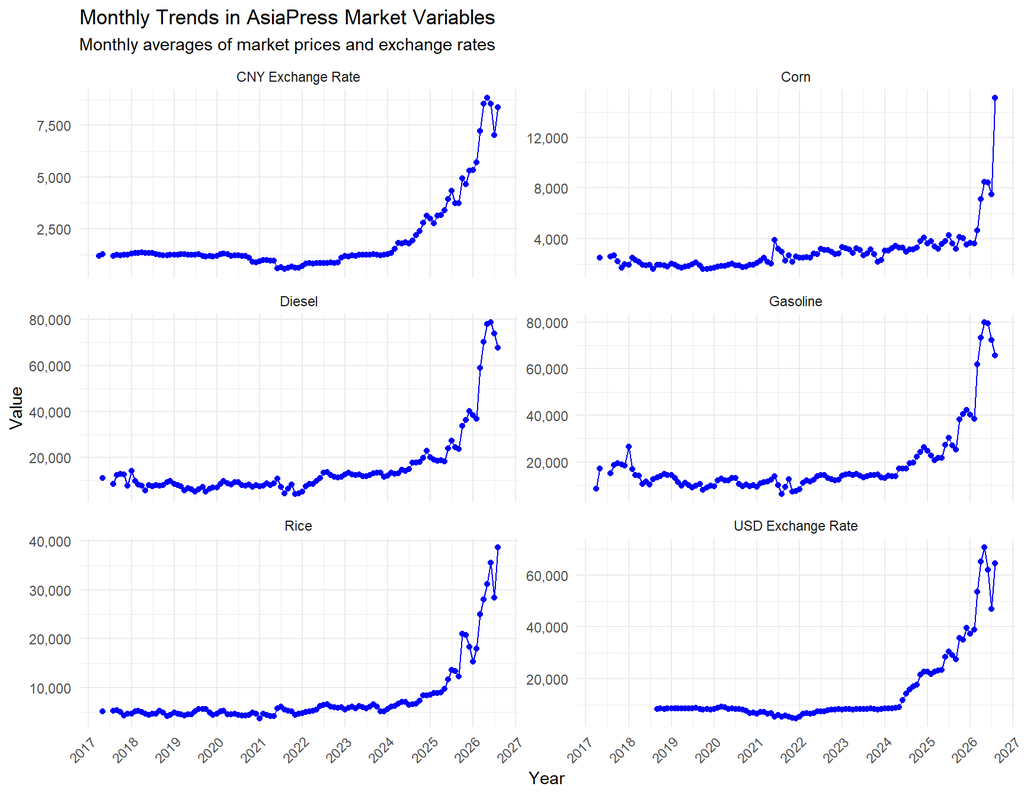

그림 1: Monthly trends in AsiaPress market variables

```r
asiapress_monthly_plot
```

The following figure compares monthly rice prices reported by Daily NK for Pyongyang, Sinuiju, and Hyesan with the supplementary AsiaPress rice price series. Because the survey locations of AsiaPress vary over time, the comparison is used only as supplementary descriptive evidence and should not be interpreted as a comparison with a fixed national or regional price series.

**코드 보기**

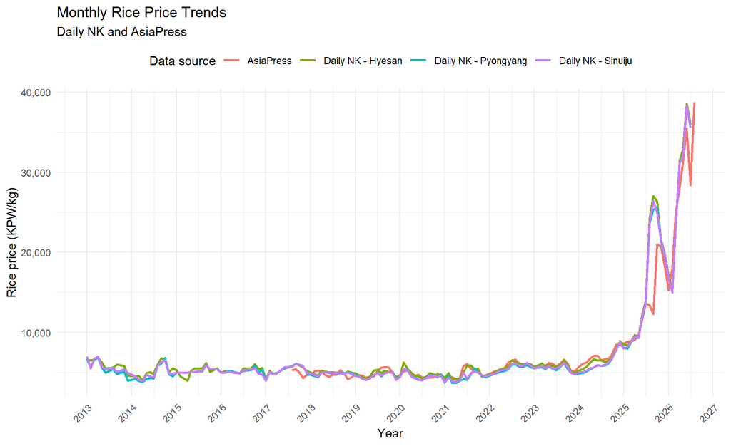

그림 2: Monthly rice price trends: Daily NK and AsiaPress

```r
# Daily NK
dailynk_rice_compare <- rice_price_monthly |>

  mutate(
    month_date = as.Date(
      paste0(month, "-01")
    )
  ) |>

  select(
    month_date,
    rice_pyongyang,
    rice_sinuiju,
    rice_hyesan
  ) |>

  pivot_longer(
    cols = starts_with("rice_"),
    names_to = "source",
    values_to = "rice_price"
  ) |>

  mutate(
    source = recode(
      source,
      rice_pyongyang = "Daily NK - Pyongyang",
      rice_sinuiju   = "Daily NK - Sinuiju",
      rice_hyesan    = "Daily NK - Hyesan"
    )
  )


# AsiaPress
asiapress_rice_compare <- asiapress_monthly |>

  mutate(
    month_date = as.Date(
      paste0(month, "-01")
    )
  ) |>

  transmute(
    month_date,
    source = "AsiaPress",
    rice_price = rice_asiapress
  )


# Combine the two data sources
rice_price_comparison <- bind_rows(
  dailynk_rice_compare,
  asiapress_rice_compare
)


# Plot monthly rice price trends
rice_price_comparison_plot <- ggplot(
  rice_price_comparison,
  aes(
    x = month_date,
    y = rice_price,
    color = source
  )
) +

  geom_line(
    linewidth = 1,
    na.rm = TRUE
  ) +

  scale_x_date(
    date_breaks = "1 year",
    date_labels = "%Y"
  ) +

  scale_y_continuous(
    labels = scales::label_comma()
  ) +

  labs(
    title = "Monthly Rice Price Trends",
    subtitle = "Daily NK and AsiaPress",
    x = "Year",
    y = "Rice price (KPW/kg)",
    color = "Data source"
  ) +

  theme_minimal() +

  theme(
    axis.text.x = element_text(
      angle = 45,
      hjust = 1
    ),
    legend.position = "top"
  )


rice_price_comparison_plot
```

The following figure compares the monthly movements of rice and corn prices reported by AsiaPress.

**코드 보기**

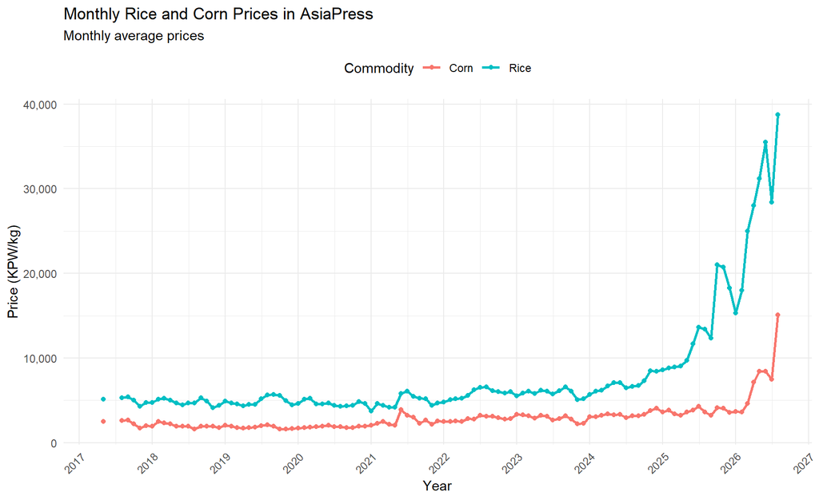

그림 3: Monthly rice and corn prices reported by AsiaPress

```r
asiapress_rice_corn_plot
```

To examine the recent food-price surge, the largest year-on-year increases in rice and corn prices are reported below. The AsiaPress series shows that rice prices entered a pronounced upward phase before the sharp increase in corn prices observed in 2026. This temporal pattern is used only as descriptive evidence and does not by itself imply a causal relationship between rice and corn prices.

**코드 보기**

```r
knitr::kable(
  recent_price_surge_table_display,

  col.names = c(
    "Commodity",
    "Month",
    "Current price",
    "Price 12 months earlier",
    "YoY change (%)"
  ),

  align = c(
    "l",
    "c",
    "c",
    "c",
    "c"
  ),

  caption = paste0(
    "Largest year-on-year increases in rice and corn prices, ",
    recent_period_label
  )
)
```

표 2: Largest year-on-year increases in rice and corn prices, 2023–2026

| Commodity | Month | Current price | Price 12 months earlier | YoY change (%) |
| --- | --- | --- | --- | --- |
| Rice | 2026-05 | 31,200.0 | 9,740.0 | 220.3 |
| Rice | 2026-04 | 28,000.0 | 9,050.0 | 209.4 |
| Rice | 2026-06 | 35,500.0 | 11,687.5 | 203.7 |
| Rice | 2026-08 | 38,750.0 | 13,400.0 | 189.2 |
| Rice | 2025-10 | 21,025.0 | 7,325.0 | 187.0 |
| Corn | 2026-08 | 15,100.0 | 3,640.0 | 314.8 |
| Corn | 2026-05 | 8,460.0 | 3,600.0 | 135.0 |
| Corn | 2026-04 | 7,137.5 | 3,225.0 | 121.3 |
| Corn | 2026-06 | 8,433.3 | 3,825.0 | 120.5 |
| Corn | 2024-12 | 4,100.0 | 2,300.0 | 78.3 |

Back to top

## 2.2 Missing precipitation treatment

### 2.2.1 Precipitation without imputation

**코드 보기**

```r
source("code/02_01_precip_raw.R")
```

Back to top

### 2.2.2 Temperature-based zero replacement

**코드 보기**

```r
source("code/02_02_precip_zero.R")
```

Back to top

### 2.2.3 Precipitation with multiple imputation

**코드 보기**

```r
source("code/02_03_precip_mi.R")
```

Back to top

### 2.2.4 Precipitation with Random Forest

**코드 보기**

```r
source("code/02_04_precip_rf.R")
```

Back to top

### 2.2.5 Precipitation with XGBoost

**코드 보기**

```r
source("code/02_05_precip_xgb.R")
```

Back to top

### 2.2.6 Validation and comparison of Precipitation treatments

**코드 보기**

```r
source("code/02_06_precip_validation.R")
```

Back to top

### 2.2.7 Missing Precipitation Treatment Summary

**코드 보기**

```r
source("code/02_07_missing_precip.R")
```

Back to top

## 2.3 Drought index construction

### 2.3.1 SPI

**코드 보기**

```r
source("code/03_01_spi.R")
```

Back to top

### 2.3.2 SPEI

**코드 보기**

```r
source("code/03_02_spei.R")
```

Back to top

### 2.3.3 SMI

**코드 보기**

```r
source("code/03_03_smi.R")
```

Back to top

### 2.3.4 Drought Indices Summary

**코드 보기**

```r
source("code/03_04_drought_indices_summary.R")
```

Back to top

## 2.4 Final dataset

**코드 보기**

```r
source("code/04_final_dataset.R")
```

Back to top

# 3. Data review

## 3.1 Descriptive statistics

**코드 보기**

```r
source("code/05_00_descriptive.R")
```

Back to top

# 4. Estimation

## 4.1 Pooled estimation

**코드 보기**

```r
source("code/06_01_pooled_estimation.R")
```

Back to top

## 4.2 Region-specific estimation

**코드 보기**

```r
source("code/06_02_region_estimation.R")
```

Back to top

## 4.3 Lagged effects

**코드 보기**

```r
source("code/06_03_lagged_effects.R")
```

Back to top

## 4.4 Robustness checks

**코드 보기**

```r
source("code/06_04_robustness.R")
```

Back to top

## 4.5 Estimation summary

**코드 보기**

```r
source("code/06_05_estimation_summary.R")
```

Back to top

# 5. Visualization

**코드 보기**

```r
source("code/07_00_plot.R")
```

Back to top